# Whole-genome sequencing reveals distinct mutational mechanisms shaping endometrial cancer

Tongwu Zhang

2026-02-09

## 1 Overview

This R Markdown document reproduces the main analyses and figures for TCGA-UCEC WGS dataset

Manuscript title: Whole-genome sequencing reveals distinct mutational mechanisms shaping endometrial cancer

## 2 Fig. 5: Whole-genome sequencing defines distinct genomic architectures across UCEC subtypes.

## 3 Load Required Libraries and Set Plotting Styles

(You may need to install some packages if missing)

```r
libztw()
library(rstatix)
pdfhr()
pdfhr2()
myggstyle()
source('./Rcode/Sherlock_functions.R')
source("./Rcode/ztw_function.R")
source("./Rcode/ztw.R")
set_wd()
```

## 4 Fig.5a

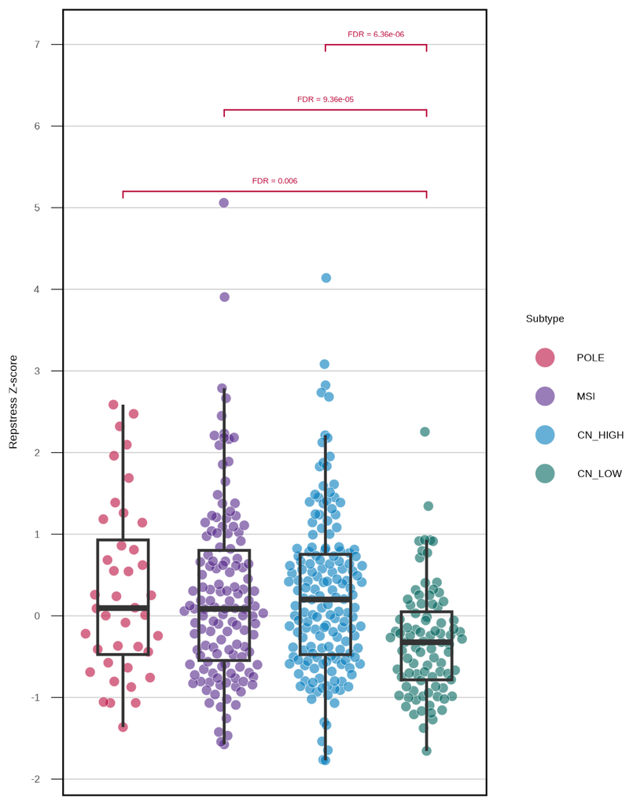

```r
##Fig5----
# TMB and replication stress --------------------------------------------
load('./Rdata/tcga_repstress_zscore.RData',verbose = T)

pdata <- ucec_tmb %>%
  mutate(TCGA_Barcode=str_sub(Tumor_Barcode,1,15)) %>%
  left_join(tcga_repstress_score_cbioportal) %>%
  filter(!is.na(RepStress_ZScore)) %>%
  left_join(subtype_data %>% select(Tumor_Barcode,Subtype))

pdata %>% group_by(Subtype) %>% do(tidy(cor.test(.$RepStress_ZScore, .$TMB,data=.))) %>% arrange((p.value))

res_depth <- plot_group_compare(
  tdata       = pdata,
  value       = RepStress_ZScore,
  group       = "Subtype",
  ylab        = "Repstress Z-score",
  hide_ns    = TRUE,
  palette     = subtype_color,
  pcol_sig    = ncicolpal[1],
  output_file = "./Rscripts/Figures/Fig5a.png",
  width       = 4,
  height      = 5,
  y_pos_adjust = c(5, 6, 5.2, 8, 5.8, 6.2)
)
```

#Fig.5a, Replication stress Z-scores across UCEC molecular subtypes. Each point represents an individual tumor. Boxplots indicate the median and interquartile range. Pairwise statistical comparisons were performed using two-sided Wilcoxon rank-sum tests with FDR correction.

## 5 Fig.5b

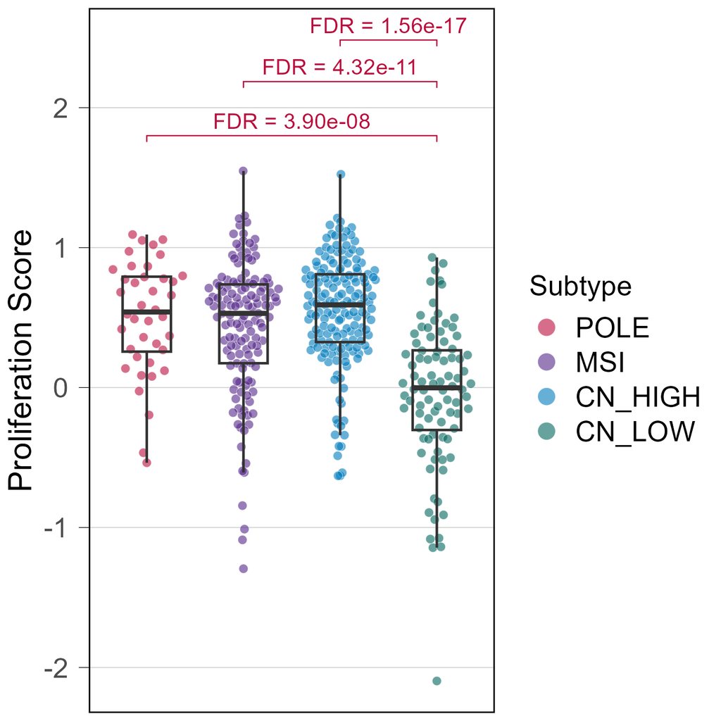

```r
# Proliferation score -----------------------------------------------------
tdata <- read_delim('./Jian/UCEC_Proliferation_Only.txt',delim = '\t')

tdata <- tdata %>%
  left_join(
    subtype_data %>% select(Subject,Subtype)
  ) %>%
  dplyr::filter(!is.na(Subtype))

res_burden2 <- plot_group_compare(
  tdata       = tdata,
  value       = Alteration,
  group       = "Subtype",
  #facet =     "Gene",
  #FDR_facet = T,
  #facet_ncol = 2,
  ylab        = "Proliferation Score",
  hide_ns    = T,
  palette     = subtype_color,
  pcol_sig    = ncicolpal[1],
  #facet_scales = 'free_y',
  output_file = "./Rscripts/Figures/Fig5b.png",
  #y_pos_adjust = c(3,60,7,5),
  width       = 5,
  height      = 5,
  p_off = F
)
```

#Fig.5b, Proliferation scores across UCEC molecular subtypes, derived from proliferation-related gene expression signatures. Each point represents one tumor. Boxplots summarize the distribution within each subtype. FDR-adjusted P values are shown.

## 6 Fig.5c

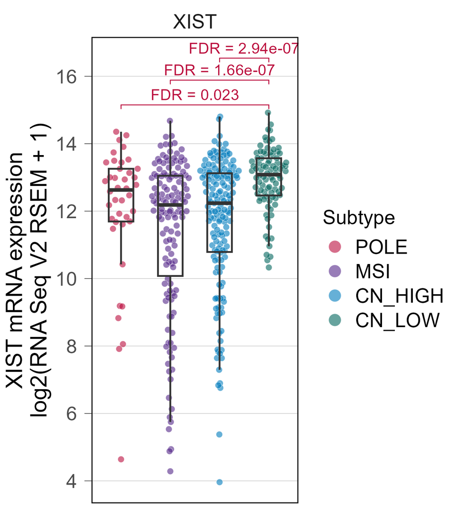

```r
load('./Rdata/ucec_RNAseq.RData')
load('./Rdata/ucec_subtype_data.RData')
# XCI: XIST ---------------------------------------------------------------
markers <- c('XIST')

tdata <- subtype_data %>%
  left_join(
    rdata %>% filter(Hugo_Symbol %in% markers) %>% mutate(RSEM=log2(RSEM+1))
  ) #%>%
#filter(Subtype == 'MSI')


# box plot show the difference

plot_group_compare(
  tdata       = tdata %>% filter(Hugo_Symbol == 'XIST'),
  value       = RSEM,
  group       = "Subtype",
  facet       = "Hugo_Symbol",facet_ncol = 7,
  ylab        = "XIST mRNA expression\nlog2(RNA Seq V2 RSEM + 1)",
  hide_ns    = TRUE,
  palette     = subtype_color,
  pcol_sig    = ncicolpal[1],
  output_file = "./Rscripts/Figures/Fig5c.png",
  width       = 4.5,
  height      = 5
  #y_pos_adjust = c(80,150)
)
```

#Fig.5c, Expression of XIST across UCEC molecular subtypes. Each point represents one tumor. Boxplots indicate median and interquartile range. FDR-adjusted P values for pairwise comparisons are shown.

## 7 Fig.5d

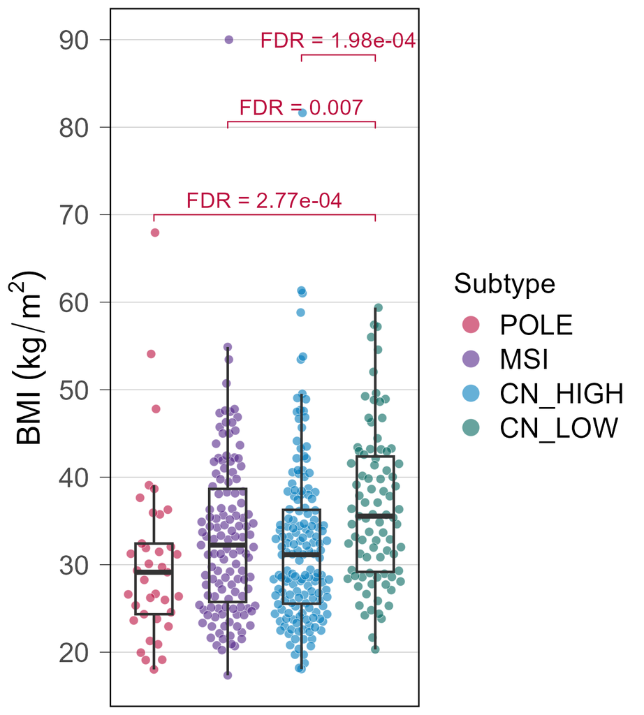

```r
load('./Rdata/ucec_subtype_data.RData',verbose = T)
# BMI ---------------------------------------------------------------------
bmidata <- read_delim('./merge_ucec_activity_all_obs_association_subtype_data.txt',delim = '\t') %>%
  select(TCGA_ID:Subtype) %>%
  mutate(Subtype=factor(Subtype,levels = c('POLE','MSI','CN_HIGH','CN_LOW'))) %>%
  mutate(BMI=as.numeric(BMI)) %>%
  mutate(BMI_Class = factor(BMI_Class,levels = c('normal','overweight','obese')))

res_burden2 <- plot_group_compare(
  tdata       = bmidata %>% filter(!is.na(BMI)) %>% mutate(BMI=if_else(BMI>200,90,BMI)),
  value       = BMI,
  group       = "Subtype",
  #facet =     "Gene",
  #FDR_facet = T,
  #facet_ncol = 2,
  ylab        = expression(BMI~(kg/m^2)),
  hide_ns    = T,
  palette     = subtype_color,
  pcol_sig    = ncicolpal[1],
  #facet_scales = 'free_y',
  output_file = "./Rscripts/Figures/Fig5d.png",
  y_pos_adjust = c(88,91,95,99,102,106)-25,
  width       = 4.5,
  height      = 5,
  p_off = F
)
```

#Fig.5d, Distribution of body mass index (BMI) across UCEC molecular subtypes. Each point represents an individual patient. Boxplots summarize the distribution within each subtype. FDR-adjusted P values for pairwise comparisons are indicated.

## 8 Fig.5e

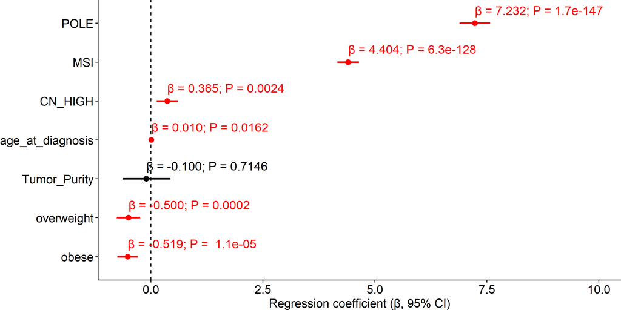

```r
load('./Rdata/ucec_burden.RData',verbose = T)
load('./Rdata/wgs_clinical.RData',verbose = T)
load('./Rdata/wgs_covdata.RData',verbose = T)
bmidata <- read_delim('./Jian/merge_ucec_activity_all_obs_association_subtype_data.txt',delim = '\t') %>%
  select(TCGA_ID:Subtype) %>%
  mutate(Subtype=factor(Subtype,levels = c('POLE','MSI','CN_HIGH','CN_LOW'))) %>%
  mutate(BMI=as.numeric(BMI)) %>%
  mutate(BMI_Class = factor(BMI_Class,levels = c('normal','overweight','obese')))

tdata <- ucec_burden %>%
  left_join(bmidata %>% select(Subject,BMI,BMI_Class)) %>%
  filter(!is.na(BMI)) %>%
  left_join(ucec_burden) %>%
  left_join(wgs_covdata) %>%
  mutate(Subtype=factor(Subtype,levels = c('CN_LOW','CN_HIGH','MSI','POLE')))

tdata %>% group_by(name) %>% do(tidy(lm(value ~ BMI+age_at_diagnosis+Tumor_Purity+Subtype,data=.))) %>% filter(term=='BMI') %>% arrange(p.value)

pdata <- tdata %>%
  group_by(name) %>%
  do(tidy(lm(value ~ (BMI_Class)+age_at_diagnosis+Tumor_Purity+Subtype,data=.),conf.int = TRUE, conf.level = 0.95, exponentiate = FALSE)) %>%
  filter(name=="TMB\nlog2(mutations/Mb)") %>%
  #arrange(p.value) %>%
  ungroup() %>%
  mutate(term=str_remove(str_remove(term,'Subtype'),'BMI_Class')) %>%
  filter(term != "(Intercept)") %>%
  mutate(
    sig = p.value < 0.05,
    term = fct_reorder(term, estimate),      # order rows by estimate (or use p.value if you prefer)
    y = as.numeric(term),
    # put label slightly ABOVE the CI line (nudged upward in y)
    y_lab = y + 0.22,
    lab = sprintf("β = %.3f; P = %s", # [%.3f, %.3f]
                  estimate,# conf.low, conf.high,
                  format.pval(p.value, digits = 2, eps = 1e-300))
  )



ggplot(pdata, aes(x = estimate, y = term)) +
  geom_vline(xintercept = 0, linetype = "dashed", linewidth = 0.5) +
  # CI line (colored by significance)
  geom_errorbarh(aes(xmin = conf.low, xmax = conf.high, color = sig),
                 height = 0, linewidth = 0.9) +
  # Point (colored by significance)
  geom_point(aes(color = sig), size = 2.6) +
  # Text ABOVE the CI line (same significance color)
  geom_text(aes(y = y_lab, label = lab, color = sig),
            hjust = 0,vjust=0, size = 5, lineheight = 0.95) +
  # leave room on the right for text labels
  scale_x_continuous(expand = expansion(mult = c(0.05, 0.35))) +
  scale_color_manual(values = c(`FALSE` = "black", `TRUE` = "red"), guide = "none") +
  labs(
    x = "Regression coefficient (β, 95% CI)",
    y = NULL,
    #title = "Forest plot: TMB log2(mutations/Mb) model terms"
  ) +
  theme_classic(base_size = 12,base_family = 'Roboto Consend') +
  theme(
    axis.text.y = element_text(size = 14),
    axis.text.x = element_text(size = 14),
    axis.title.x = element_text(size=14)
  )

ggsave(filename = './Rscripts/Figures/Fig5e.png',width = 10,height = 5)
```

#Fig.5e, Multivariable regression analysis assessing associations with tumor mutational burden (TMB). Variables include UCEC molecular subtype (reference = CN-Low), age at diagnosis, tumor purity, and BMI class (reference = normal). Points represent regression coefficients (β), and horizontal lines indicate 95% confidence intervals. Two-sided P values are shown.

## 9 Fig.5f

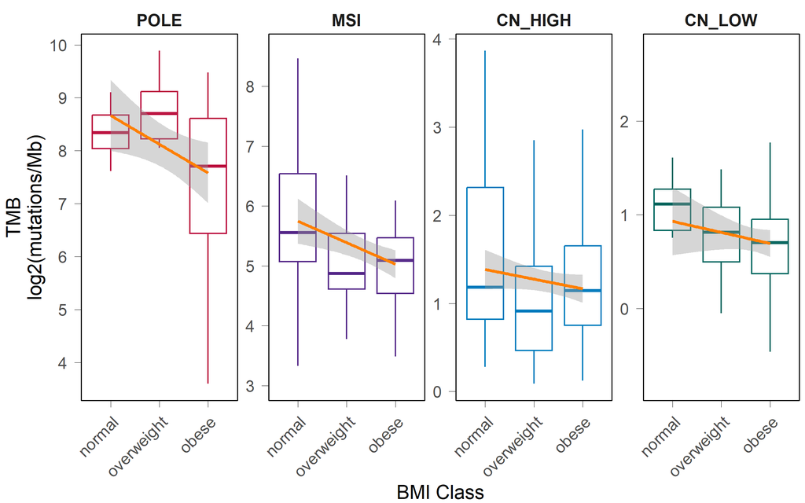

```r
load('./Rdata/ucec_subtype_data.RData',verbose = T)
tdata %>%
  mutate(Subtype=factor(Subtype,levels = c('POLE','MSI','CN_HIGH','CN_LOW'))) %>%
  filter(name=="TMB\nlog2(mutations/Mb)") %>%
  ggplot(aes(BMI_Class,value,col=Subtype))+
  geom_boxplot(outlier.color = NA)+
  scale_y_continuous(breaks = pretty_breaks())+
  scale_color_manual(values = subtype_color)+
  geom_smooth(method = "lm", se=TRUE, aes(group=1),col=ncicolpal[2])+
  labs(x='BMI Class', y='TMB\nlog2(mutations/Mb)')+
  facet_wrap(~Subtype,scale='free',nrow=1)+
  theme_ipsum_rc(axis_title_just = "m", axis_title_size = 14, ticks = TRUE, grid = FALSE) +
  theme(
    panel.spacing = unit(0.4, "lines"),
    strip.background = element_blank(),
    strip.text = element_text(hjust = 0.5, face = "bold"),
    plot.margin = margin(4, 4, 0, 4),
    axis.text.x = element_text(angle = 45,hjust = 1,vjust = 1),
    legend.position = "none"
  ) +
  ggpubr::border(color = "black", size = 0.35) +
  coord_cartesian(clip = "off")

ggsave(filename = './Rscripts/Figures/Fig5f.png',width = 8,height = 5)
```

#Fig.5f, Association between BMI class (normal, overweight, obese) and tumor mutational burden within each UCEC molecular subtype. Boxplots show log₂-transformed TMB (mutations per megabase). Solid lines indicate fitted trends across BMI classes within each subtype, with shaded regions representing 95% confidence intervals.